# Exploration_WFM1

Milton Osiel Candela Leal

7/17/2021

## Packages used

The following packages were used:

```r
library(R.matlab)
library(dplyr)
library(caret)
library(MASS)
```

## Reading information

The information is on **.mat** files, and so it must be transformed into a Data Frames via **R.matlab** and **dplyr** packages.

```r
data <- readMat('Data/Raw/FeatureMatrices.mat')

unmin <- as.data.frame(data$WFM.1) # Using the first document of 1 minute

feature_names <- unlist(data$FMinfo) # Get column names
colnames(unmin) <- feature_names

unmin <- as.data.frame(unmin)
unmin <- mutate(unmin, Clas = as.factor(Clas)) # Transform the predicted variable to a factor

unmin <- unmin[,c(1:120,length(colnames(unmin)))] # Remove Empatica's variables (EDA TEMP HR HF)

print(head(unmin))
```

```
##   Delta (FP2) Delta (FP1)    Delta (C4)   Delta (C3)   Delta (P8)   Delta (P7)
## 1  0.11643540 -0.10807710 -0.0007967785 -0.021824544 -0.052001271 -0.052366123
## 2  0.08216888  0.09031544 -0.0685819650 -0.025703930 -0.032567698 -0.125933534
## 3  0.13396455  0.03674585  0.1240085263  0.090566646  0.008587199  0.273517209
## 4  0.08577410  0.04645360  0.0868305541  0.028435993  0.065335451  0.215342637
## 5  0.08974345  0.10104639  0.0002082496 -0.008906065  0.001834152  0.004868526
## 6  0.02974833 -0.12397229 -0.0798713713  0.032517547 -0.004881908  0.039584253
##    Delta (O1)  Delta (O2) Theta (FP2) Theta (FP1)   Theta (C4)   Theta (C3)
## 1 -0.14262681 -0.06574524  0.06979229 -0.10023482  0.028478698 -0.092361944
## 2 -0.03696367 -0.03600595  0.07782443  0.02637755 -0.133740130 -0.023413436
## 3  0.19458963  0.16689514  0.13841042  0.05687610  0.143305425  0.113590601
## 4  0.17783968  0.02827166 -0.02372679  0.02989482  0.026600574 -0.001333520
## 5 -0.07280683 -0.08045784  0.09114603  0.07725917 -0.008292030  0.002163053
## 6  0.02801259 -0.01867924 -0.03278990 -0.24379312 -0.007344334 -0.027462357
##    Theta (P8)  Theta (P7)  Theta (O1)   Theta (O2)  Alpha (FP2)   Alpha (FP1)
```

[output cut: 104 more lines]

## Information partitioning

We further use the **caret** package in order to divide the whole dataset into a separate training and testing dataset, a seed is used to test with the same division of data.

```r
set.seed(1002)

trainIndex <- createDataPartition(unmin$Clas, p = 0.75, list = FALSE)
training <- unmin[trainIndex,]
testing <- unmin[-trainIndex,]
```

## ML models fitting

Data is already normalized, so it does not require pre-processing and can be directly used by ML algorithms. The following function tests a generated model on training and testing data, the parameters are: the ML algorithm and *k*, the number of cross-validations used.

A further for loop iterate three algorithms (rf, gmb, lda) with an incremental number of cross-validations, from 2 to **n_max**.

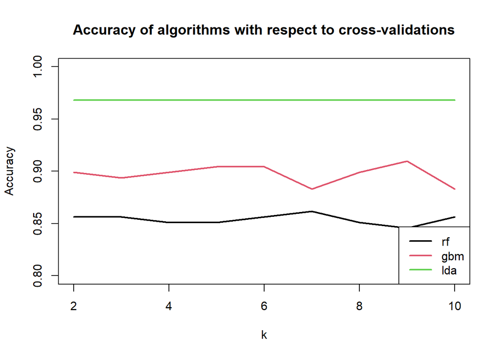

```r
prob_modelo <- function(training, met, testing, control){
     if(met == 'gbm'){
          modelo <- train(Clas ~ ., data = training, method = met,
                          trControl = control, verbose = FALSE)
     } else{
          modelo <- train(Clas ~ ., data = training, method = met,
                          trControl = control)}
     Pred <- predict(modelo, testing)
     acc <- round(confusionMatrix(testing$Clas, Pred)$overall[1], 5)
     return(acc)
}

n_max <- 10 # Maximum number of cross-validations (CVs)
metodos <- c('rf', 'gbm', 'lda')
df <- data.frame('rf' = 2:n_max, 'gbm' = 2:n_max, 'lda' = 2:n_max)

for(metodo in metodos){
        acc_l <- c()
        for(num in 2:n_max){
                control <- trainControl(method = 'cv', number = num)
                acc <- prob_modelo(training, metodo, testing, control)
                acc_l <- c(acc_l, acc) }
        df[,metodo] <- acc_l
}

plot(y = df[,1], x = 2:n_max, ylim = c(0.8, 1), xlim = c(2,10), type = 'l', col = 1, lwd = 2,
     ylab = 'Accuracy', xlab = 'k',
     main = 'Accuracy of algorithms with respect to cross-validations')
lines(y = df[,2], x = 2:n_max, col = 2, lwd = 2)
lines(y = df[,3], x = 2:n_max, col = 3, lwd = 2)
legend('bottomright', legend = c('rf', 'gbm', 'lda'), col = 1:3, lty = 1, lwd = 2)
```

As it can be seen on the plot, the LDA (Linear Discriminant Analysis) model outperformed *rf* and *gbm*, it is also not affected by the number of CVs, so it will be further analyzed.

```r
modelo_lda <- lda(Clas ~ ., data = training)
```

## Model evaluation

In order to visualize the LDAs predictions, we obtain the two most relevant components (LDA1 and LDA), create a plot of the transformed values and its predicted class on training data.

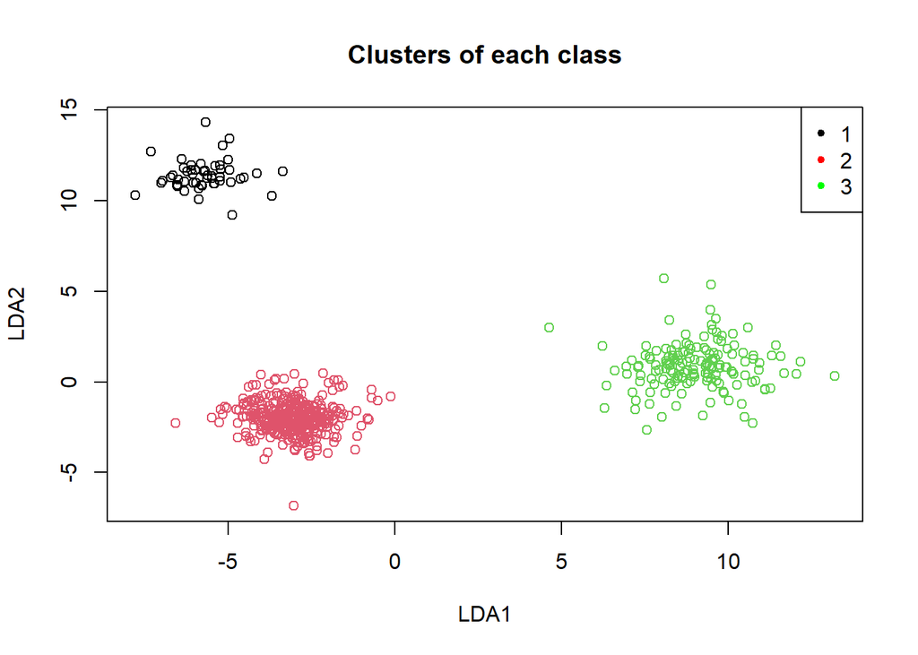

```r
valores <- predict(modelo_lda)

plot(valores$x[,1], valores$x[,2], col = training$Clas, xlab = 'LDA1', ylab = 'LDA2',
     main = 'Clusters of each class')
legend('topright', legend = c(1:3), col = c('black', 'red', 'green'), pch = 20)
```

Using the current weights, the plot on testing data is affected due to an outlier, and thus we compute a confusion matrix on testing data:

```r
pred <- predict(modelo_lda, testing)
print(confusionMatrix(testing$Clas, pred$class))
```

```
## Confusion Matrix and Statistics
##
##           Reference
## Prediction   1   2   3
##          1  17   0   0
##          2   0 120   0
##          3   1   5  45
##
## Overall Statistics
##
##                Accuracy : 0.9681
##                  95% CI : (0.9318, 0.9882)
##     No Information Rate : 0.6649
##     P-Value [Acc > NIR] : < 2.2e-16
##
##                   Kappa : 0.9364
##
##  Mcnemar's Test P-Value : NA
##
## Statistics by Class:
##
##                      Class: 1 Class: 2 Class: 3
## Sensitivity           0.94444   0.9600   1.0000
## Specificity           1.00000   1.0000   0.9580
## Pos Pred Value        1.00000   1.0000   0.8824
## Neg Pred Value        0.99415   0.9265   1.0000
## Prevalence            0.09574   0.6649   0.2394
## Detection Rate        0.09043   0.6383   0.2394
## Detection Prevalence  0.09043   0.6383   0.2713
## Balanced Accuracy     0.97222   0.9800   0.9790
```

The outlier is then padded with the median of the predictions and thus the plot can be visualized.

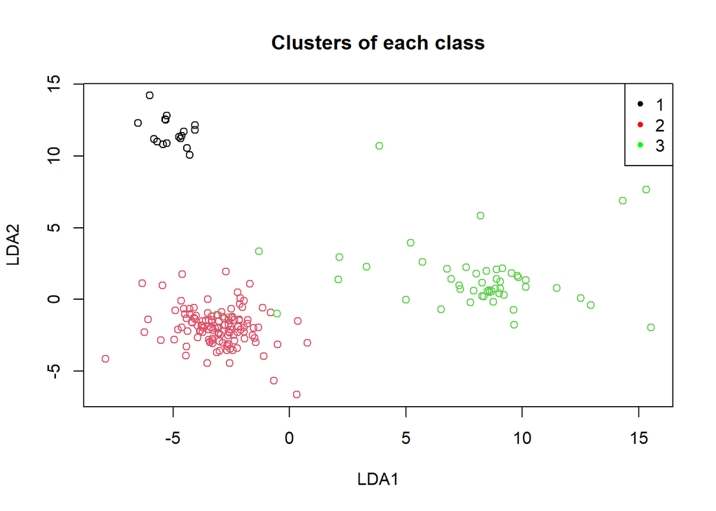

```r
outliers <- pred$x[,1] > 1000
pred$x[outliers,] <- c(median(pred$x[,1]), median(pred$x[,2]))

plot(pred$x[,1], pred$x[,2], col = testing$Clas, xlab = 'LDA1', ylab = 'LDA2',
     main = 'Clusters of each class')
legend('topright', legend = c(1:3), col = c('black', 'red', 'green'), pch = 20)
```

## Plotting the outlier

A visualization of the outlier is presented via an histogram of the value of its features.

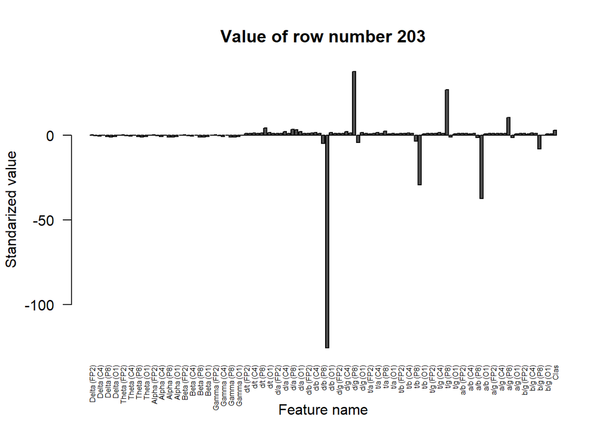

```r
out_df <- testing[outliers,]
barplot(as.matrix(out_df), las = 2, ylab = 'Standarized value', xlab = 'Feature name',
        cex.names = 0.5, main = paste('Value of row number', row.names(out_df)))
```